# Learning Week 3

Workshop

Adam La Caze

We will start this week with a discussion of noninferiority trials from the LW2 workshop.

## Learning objectives for the week

1. Understand external validity and the judgments that are necessary to support claims that a treatment is safe and effective
2. Identify sources of evidence that will be important in assessing the external validity of a trial and informing judgments that a treatment is safe and effective
3. Be able to describe the roles of cohort and case control studies
4. Be able to evaluate key sources of bias in cohort and case control studies
5. Be able to calculate prevalence and incidence of disease, and odds ratios based on the results of a case control study

## Extend activities

- Cohort and case-control studies (characteristics)
- Rimm et al. (1993)
  - Vitamin E and coronary heart disease (PECOT)
  - Sources of bias and impact of specific kinds of bias
- de Abajo, Rodríguez, and Montero (1999)
  - PECOT
  - Sources of bias
- SSRIs and falls: types of bias
- Odds ratio: Piccinni et al. (2011)

# Noninferiority trials

## RE-LY Trial (Connolly et al. 2009)

A brief PICO for the RE-LY Trial:

- **Participants** Adults with atrial fibrillation and a risk of stroke
- **Intervention** Dabigatran 110 mg BD or 150 mg BD
- **Comparator** Adjusted-dose warfarin
- **Outcomes** Stroke or systemic embolism

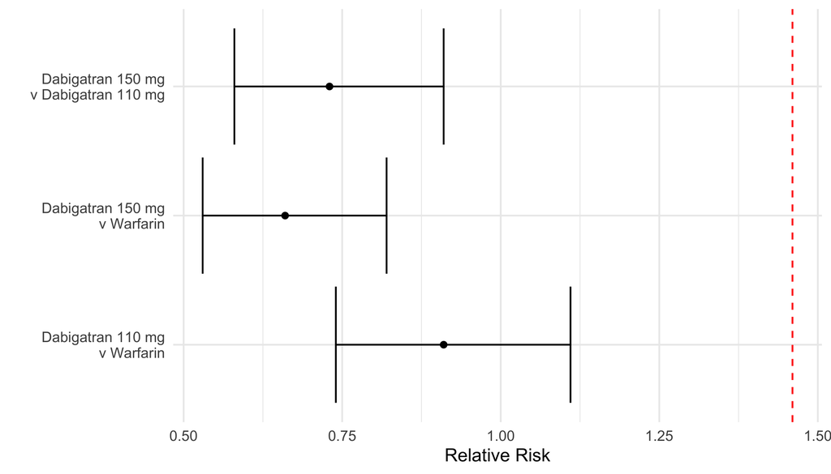

Interpret the results of the RE-LY trial for the primary endpoint.

Indicate whether the intervention is noninferior or superior to the comparator (the “intervention” is listed first in the comparisons).

Explain the red dotted line at RR = 1.46 (Is it justified?)

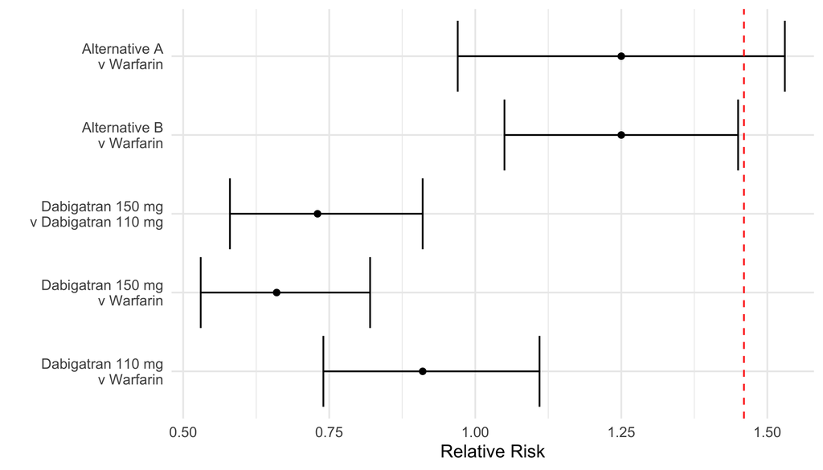

# Critical appraisal

## Zinman et al. (2015)

Critically appraise Zinman et al. (2015)

1. Provide a structured summary of the study
2. Critically appraise the trial. Evaluate the internal validity of the trial.
3. Calculate and describe the clinically relevant results
4. Synthesise the relevant literature and explain the contribution of the study (we will do this in the LW4 workshop)

## PICO

[output not shown]

## Statistical details

> The primary hypothesis was noninferiority for the primary outcome with empagliflozin (pooled doses of 10 mg and 25 mg) versus placebo with a margin of 1.3 for the hazard ratio.

## Internal validity

- Does the PICO make sense? (Does the study make sense?)
- Are the groups comparable?
  - Was the allocation of participants randomized?
  - Were the groups similar at the start of the trial?
  - Aside from allocated treatment, were groups treated equally?
  - Were all participants who entered the trial accounted for?–and were they analysed in the groups to which they were randomized?
- What did the study measure? Is it reliable?
  - Is the primary endpoint a clinical outcome?
  - Were the measures objective?
  - Were participants, investigators and trial staff masked from treatment allocation?

## Key questions

- Why was the study set up to assess emagliflozin as noninferior to placebo?
- Is it appropriate to combine the outcomes for empagliflozin 10 mg and 25 mg?

## Results

The primary outcome occurred in a significantly lower percentage of patients in the empagliflozin group (490 of 4687 [10.5%]) than in the placebo group (282 of 2333 [12.1%]) (hazard ratio in the empagliflozin group, 0.86; 95.02% confidence interval [CI], 0.74 to 0.99; P<0.001 for noninferiority and P = 0.04 for superiority)

## Measures of effect

| Measure | Data |
| --- | --- |
| Event rate (intervention) | 10.50 |
| Event rate (control) | 12.10 |
| Relative risk | 0.87 |
| Relative risk reduction | 13.00 |
| Absolute risk reduction | 1.60 |
| Number needed to treat | 62.00 |

- Ensure you put the NNT into words
- Ensure you discuss the observed harms (and put the harms and benefits into context)

# Odds ratio

## Long-term benzodiazepines use and dementia diagnosis

A case control study sought to assess the association between long-term benzodiazepine use and a diagnosis of dementia.

Cases were people diagnosed with dementia. For each person diagnosed with dementia, six controls were randomly selected.

Benzodiazepine use was assessed prior to dementia diagnosis for cases. Long-term benzodiazepine use was defined as use for more than 180 days in any 1-year period.

779 people with a diagnosis of dementia were identified in the database. Of these cases 267 were long-term benzodiazepine users.

4626 controls were randomly selected (none of the controls had a diagnosis of dementia). 852 controls were long-term benzodiazpine users.

Calculate the crude odds ratio for the association between long-term benzodiazepine use and diagnosis of dementia.

Identify (i) possible sources of bias in the study described and (ii) how these sources of bias might be addressed

## $2 \times 2$ table: case-control study

|  | Case | Non-case |
| --- | --- | --- |
| Exposed | $a$ | $b$ |
| Not exposed | $c$ | $d$ |
| Total | $(a + c)$ | $(b + d)$ |

$$O_{cases} = \frac{a}{c}$$

$$O_{control} = \frac{b}{d}$$

$$OR = \frac{O_{cases}}{O_{control}} =
\frac{ad}{bc}$$

## Calculation

|  | **Dx** | **No Dx** |
| --- | --- | --- |
| Exposure | 267 | 852 |
| Not exposed | 512 | 3774 |
| **Total** | 779 | 4626 |

$$OR = \frac{O_{cases}}{O_{control}} =
\frac{ad}{bc}$$

$$OR = \frac{267 \times 3774}{852\times
512}$$

$$OR = 2.31$$

## References

Abajo, F J de, L A Rodríguez, and D Montero. 1999. “Association Between Selective Serotonin Reuptake Inhibitors and Upper Gastrointestinal Bleeding: Population Based Case-Control Study.” *British Medical Journal (Clinical Research Ed.)* 319 (7217): 1106–9. https://doi.org/10.1136/bmj.319.7217.1106.

Connolly, Stuart J., Michael D. Ezekowitz, Salim Yusuf, John Eikelboom, Jonas Oldgren, Amit Parekh, Janice Pogue, et al. 2009. “Dabigatran Versus Warfarin in Patients with Atrial Fibrillation.” *New England Journal of Medicine* 361 (12): 1139–51. https://doi.org/10.1056/NEJMoa0905561.

Piccinni, Carlo, Domenico Motola, Giulio Marchesini, and Elisabetta Poluzzi. 2011. “Assessing the Association of Pioglitazone Use and Bladder Cancer Through Drug Adverse Event Reporting.” *Diabetes Care* 34 (6): 1369–71. https://doi.org/10.2337/dc10-2412.

Rimm, Eric B., Meir J. Stampfer, Alberto Ascherio, Edward Giovannucci, Graham A. Colditz, and Walter C. Willett. 1993. “Vitamin E Consumption and the Risk of Coronary Heart Disease in Men.” *New England Journal of Medicine* 328 (20): 1450–56. https://doi.org/10.1056/NEJM199305203282004.

Zinman, Bernard, Christoph Wanner, John M. Lachin, David Fitchett, Erich Bluhmki, Stefan Hantel, Michaela Mattheus, et al. 2015. “Empagliflozin, Cardiovascular Outcomes, and Mortality in Type 2 Diabetes.” *New England Journal of Medicine* 373 (22): 2117–28. https://doi.org/10.1056/NEJMoa1504720.